# augmentation

## Image Augmentation

This is a simple image augmentation example using https://github.com/codebox/image_augmentor

This tool scans a directory containing image files, and generates new images by performing a specified set of augmentation operations on each file that it finds.

Run the utility from the command-line as follows:

```
python main.py <image dir> <transform1> <transform2> ...
```

The `<image dir>` is the path to the directory image files to be augmented.

The `transform` arguments determine what types of transformation operations are applied.

| Code | Description | Example Values |
| --- | --- | --- |
| `fliph` | Horizontal Flip | `fliph` |
| `flipv` | Vertical Flip | `flipv` |
| `noise` | Adds random noise to the image | `noise_0.01`,`noise_0.5` |
| `rot` | Rotates the image by the specified amount | `rot_90`,`rot_-45` |
| `trans` | Shifts the pixels of the image by the specified amounts in the x and y directions | `trans_20_10`,`trans_-10_0` |
| `zoom` | Zooms into the specified region of the image, performing stretching/shrinking as necessary | `zoom_0_0_20_20`,`zoom_-10_-20_10_10` |
| `blur` | Blurs the image by the specified amount | `blur_1.5` |

This notebook will demonstrate the transformations

```python
%matplotlib inline

from PIL import Image
import matplotlib
import numpy as np
import matplotlib.pyplot as plt
import warnings
warnings.filterwarnings('ignore')
```

```python
def subplotImage(image,ax):
    ax.set_yticklabels([])
    ax.set_xticklabels([])
    ax.axis('off')
    ax.imshow(image)
```

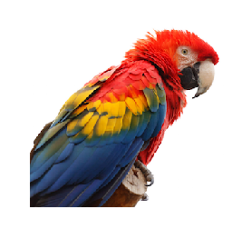

```python
img = Image.open('/demo/aug_images/bird.png')
img = np.array(img)
plt.axis('off')
plt.imshow(img)
plt.show()
```

### Operations

#### Horizontal Flip

Mirrors the image around a vertical line running through its center

```
python main.py image_dir fliph
```

```
Thread pool initialised with 1 worker
Processing /demo/aug_images...
Waiting for workers to complete...
{'skipped_no_match': 0, 'processed': 1, 'skipped_augmented': 17, 'error': 0}
```

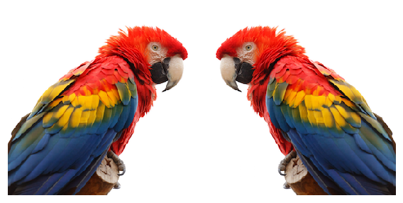

```python
%run /demo/image_augmentor/main.py /demo/aug_images  fliph

img2 = Image.open('/demo/aug_images/bird__fliph.png')
img2 = np.array(img2)

# show the images
f, axarr = plt.subplots(1,2)
f.set_figheight(8)
f.set_figwidth(8)


#orig
subplotImage(img,axarr[0])
# new
subplotImage(img2,axarr[1])

plt.tight_layout()
plt.show()
```

#### Vertical Flip

Mirrors the image around a horizontal line running through its center

```
python main.py image_dir flipv
```

```
Thread pool initialised with 1 worker
Processing /demo/aug_images...
Waiting for workers to complete...
{'skipped_no_match': 0, 'processed': 1, 'skipped_augmented': 17, 'error': 0}
```

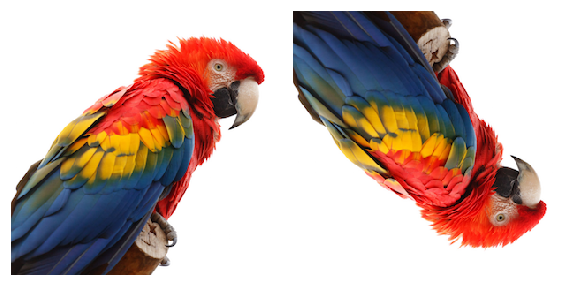

```python
%run /demo/image_augmentor/main.py /demo/aug_images  flipv

img2 = Image.open('/demo/aug_images/bird__flipv.png')
img2 = np.array(img2)

# show the images
f, axarr = plt.subplots(1,2)
f.set_figheight(8)
f.set_figwidth(8)


#orig
subplotImage(img,axarr[0])
# new
subplotImage(img2,axarr[1])

plt.tight_layout()
plt.show()
```

#### Noise

Adds random noise to the image. The amount of noise to be added is specified by a floating-point numeric value that is included in the argument.

```
python main.py image_dir noise_0.01 noise_0.02 noise_0.05
```

```
Thread pool initialised with 1 worker
Processing /demo/aug_images...
Waiting for workers to complete...
{'skipped_no_match': 0, 'processed': 1, 'skipped_augmented': 17, 'error': 0}
```

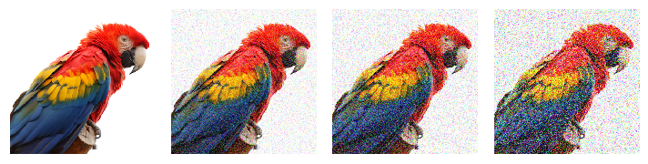

```python
%run /demo/image_augmentor/main.py /demo/aug_images  noise_0.01 noise_0.02 noise_0.05
img2 = Image.open('/demo/aug_images/bird__noise0.01.png')
img3 = Image.open('/demo/aug_images/bird__noise0.02.png')
img4 = Image.open('/demo/aug_images/bird__noise0.05.png')
# show the images
#plt.figure(figsize=(100,100))
f, axarr = plt.subplots(1,4)
f.set_figheight(10)
f.set_figwidth(10)
#orig
subplotImage(img,axarr[0])
# new
subplotImage(img2,axarr[1])
subplotImage(img3,axarr[2])
subplotImage(img4,axarr[3])
plt.tight_layout()
plt.show()
```

#### Rotate

Rotates the image. The angle of rotation is specified by a integer value that is included in the argument. This value can be positor or negative.

```
python main.py image_dir rot_90 rot_180 rot_-90
```

```
Thread pool initialised with 1 worker
Processing /demo/aug_images...
Waiting for workers to complete...
{'skipped_no_match': 0, 'processed': 1, 'skipped_augmented': 17, 'error': 0}
```

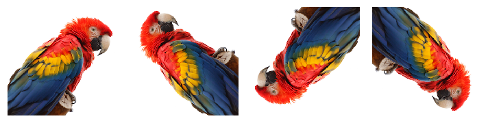

```python
%run /demo/image_augmentor/main.py /demo/aug_images  rot_90 rot_180 rot_-90
img2 = Image.open('/demo/aug_images/bird__rot-90.png')
img3 = Image.open('/demo/aug_images/bird__rot180.png')
img4 = Image.open('/demo/aug_images/bird__rot90.png')
# show the images
#plt.figure(figsize=(100,100))
f, axarr = plt.subplots(1,4)
f.set_figheight(10)
f.set_figwidth(10)
#orig
subplotImage(img,axarr[0])
# new
subplotImage(img2,axarr[1])
subplotImage(img3,axarr[2])
subplotImage(img4,axarr[3])
plt.tight_layout()
plt.show()
```

#### Translate

Performs a translation on the image. The size of the translation in the x and y directions are specified by integer values that are included in the argument

```
python main.py image_dir trans_20_20 trans_0_100
```

```
Thread pool initialised with 1 worker
Processing /demo/aug_images...
Waiting for workers to complete...
{'skipped_no_match': 0, 'processed': 1, 'skipped_augmented': 17, 'error': 0}
```

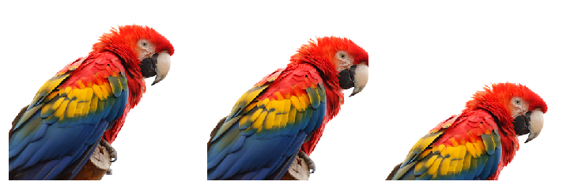

```python
%run /demo/image_augmentor/main.py /demo/aug_images  trans_20_20 trans_0_100
img2 = Image.open('/demo/aug_images/bird__trans20_20.png')
img3 = Image.open('/demo/aug_images/bird__trans0_100.png')


# show the images
#plt.figure(figsize=(100,100))
f, axarr = plt.subplots(1,3)
f.set_figheight(10)
f.set_figwidth(10)
#orig
subplotImage(img,axarr[0])
# new
subplotImage(img2,axarr[1])
subplotImage(img3,axarr[2])
plt.tight_layout()
plt.show()
```

#### Zoom/Stretch

Zooms in (or out) to a particular area of the image. The top-left and bottom-right coordinates of the target region are specified by integer values included in the transform argument. By specifying a target region with an aspect ratio that differs from that of the source image, stretching transformations can be performed.

```
python main.py image_dir zoom_150_0_300_150 zoom_0_50_300_150 zoom_200_0_300_300
```

```
Thread pool initialised with 1 worker
Processing /demo/aug_images...
Waiting for workers to complete...
{'skipped_no_match': 0, 'processed': 1, 'skipped_augmented': 17, 'error': 0}
```

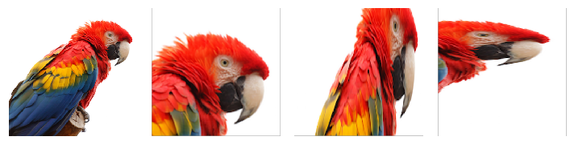

```python
%run /demo/image_augmentor/main.py /demo/aug_images  zoom_150_0_300_150 zoom_0_50_300_150 zoom_200_0_300_300
img2 = Image.open('/demo/aug_images/bird__zoom150_0_300_150.png')
img3 = Image.open('/demo/aug_images/bird__zoom0_50_300_150.png')
img4 = Image.open('/demo/aug_images/bird__zoom200_0_300_300.png')
# show the images
#plt.figure(figsize=(100,100))
f, axarr = plt.subplots(1,4)
f.set_figheight(10)
f.set_figwidth(10)
#orig
subplotImage(img,axarr[0])
# new
subplotImage(img2,axarr[1])
subplotImage(img3,axarr[2])
subplotImage(img4,axarr[3])
plt.tight_layout()
plt.show()
```

#### Blur

Blurs the image. The amount of blurring is specified by a floating-point value included in the argument.

```
python main.py image_dir blur_1.0 blur_2.0 blur_4.0
```

```
Thread pool initialised with 1 worker
Processing /demo/aug_images...
Waiting for workers to complete...
{'skipped_no_match': 0, 'processed': 1, 'skipped_augmented': 13, 'error': 0}
```

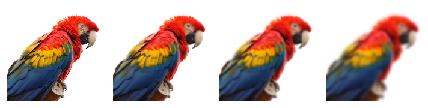

```python
%run /demo/image_augmentor/main.py /demo/aug_images  blur_1.0 blur_2.0 blur_4.0

img2 = Image.open('/demo/aug_images/bird__blur1.0.png')
img3 = Image.open('/demo/aug_images/bird__blur2.0.png')
img4 = Image.open('/demo/aug_images/bird__blur4.0.png')
# show the images
#plt.figure(figsize=(100,100))
f, axarr = plt.subplots(1,4)
f.set_figheight(10)
f.set_figwidth(10)
#orig
subplotImage(img,axarr[0])
# new
subplotImage(img2,axarr[1])
subplotImage(img3,axarr[2])
subplotImage(img4,axarr[3])
plt.tight_layout()
plt.show()
```

#### Compound Example

Produce a single output image for each input image after applying a series for transformations.  
For example, rotating the image by 90° and then flipping it horizontally

```
python main.py image_dir  rot_90,fliph
```

```
Thread pool initialised with 1 worker
Processing /demo/aug_images...
Waiting for workers to complete...
{'skipped_no_match': 0, 'processed': 1, 'skipped_augmented': 16, 'error': 0}
```

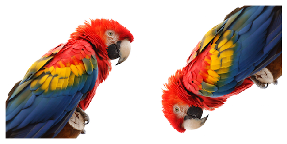

```python
%run /demo/image_augmentor/main.py /demo/aug_images  rot_90,fliph


img2 = Image.open('/demo/aug_images/bird__rot90__fliph.png')
img2 = np.array(img2)

# show the images
f, axarr = plt.subplots(1,2)
f.set_figheight(8)
f.set_figwidth(8)


#orig
subplotImage(img,axarr[0])
# new
subplotImage(img2,axarr[1])

plt.tight_layout()
plt.show()
```